# PAWS Analysis with R-Ladies - Question 3 additional analysis

Alice Walsh

3/23/2018

```r
# This code works when you are using RStudio project. Paths are relative and stuff
library(survival)
library(survminer)
library(RColorBrewer)
suppressPackageStartupMessages(library(tidyverse))
```

# Question

What is the typical pattern for volunteer disengagement?

I need to summarise the number of volunteers with various characteristics:

- did orientation, but no shifts
- did orientation, had only 1 shift
- did orientation, had 2+ shifts

What factors are associated with these three groups? location, orientation type, zip code, days to first shift?

For volunteers that do show up, what happens? Lets plot frequencies over the following factors:

- orientation type
- orientation location
- did a shift
- did a second shift
- shift types

How do we define a “disengaged” volunteer?

- My idea: Length of time after last shift is > x months (test different x)

# Procedure

1. Load in the data
2. Analyze

## Load Data

```r
final_data <- readRDS("../../Data/merged.Rds")
```

# Analysis

```r
final_data$event <- 0
final_data$event[final_data$days_since_last > 90] <- 1

# create factor for whether they reported for shift within 14 days
final_data$first_shift_group <- case_when(
  as.numeric(final_data$time_to_first) <= 14 ~ "<= 14 days",
  as.numeric(final_data$time_to_first) <= 60 ~ "14 to 60 days",
  as.numeric(final_data$time_to_first) > 60 ~ "> 60 days"
)
final_data$first_shift_group <- factor(final_data$first_shift_group,
                                       levels = c("<= 14 days", "14 to 60 days", "> 60 days"))

final_data$timebw_shift_group <- case_when(
  as.numeric(final_data$time_bw_median) <= 7 ~ "<= 7 days",
  as.numeric(final_data$time_bw_median) <= 14 ~ "7 to 14 days",
  as.numeric(final_data$time_bw_median) > 14 ~ "> 14 days"
)
final_data$timebw_shift_group <- factor(final_data$timebw_shift_group,
                                        levels = c("<= 7 days", "7 to 14 days", "> 14 days"))

final_data %>%
  filter(Orientation.Date.Primary <= "2017-09-01", total_shifts > 0) %>%
  group_by(first_shift_group) %>%
  summarise(mean_shifts = mean(total_shifts),
            mean_missed_shifts = mean(missed_shifts),
            freq = n()) %>%
  knitr::kable(caption = "Summary of time orientation to first shift")
```

Summary of time orientation to first shift

| first_shift_group | mean_shifts | mean_missed_shifts | freq |
| --- | --- | --- | --- |
| <= 14 days | 14.542857 | 0.4571429 | 105 |
| 14 to 60 days | 13.500000 | 0.3548387 | 62 |
| > 60 days | 8.813954 | 0.1860465 | 43 |

```r
final_data %>%
  filter(Orientation.Date.Primary <= "2017-09-01", total_shifts > 0 ) %>%
  group_by(timebw_shift_group) %>%
  summarise(mean_shifts = mean(total_shifts),
            mean_missed_shifts = mean(missed_shifts),
            freq = n()) %>%
  knitr::kable(caption = "Summary of time between shifts")
```

Summary of time between shifts

| timebw_shift_group | mean_shifts | mean_missed_shifts | freq |
| --- | --- | --- | --- |
| <= 7 days | 20.927835 | 0.5154639 | 97 |
| 7 to 14 days | 9.224490 | 0.1836735 | 49 |
| > 14 days | 6.324324 | 0.4324324 | 37 |
| NA | 1.000000 | 0.1111111 | 27 |

## Plot volunteers time between first shift and disengagement (time_last_to_first)

```r
model_data <- filter(final_data, total_shifts > 1, Orientation.Date.Primary <= "2017-09-01")
surv.model <- Surv(model_data$time_last_to_first, model_data$event)

surv.fit <- survfit(surv.model ~ first_shift_group, data = model_data)
surv.fit
```

```
## Call: survfit(formula = surv.model ~ first_shift_group, data = model_data)
##
##                                  n events median 0.95LCL 0.95UCL
## first_shift_group=<= 14 days    96     55    105      70      NA
## first_shift_group=14 to 60 days 53     23     NA     177      NA
## first_shift_group=> 60 days     34      9     NA      39      NA
```

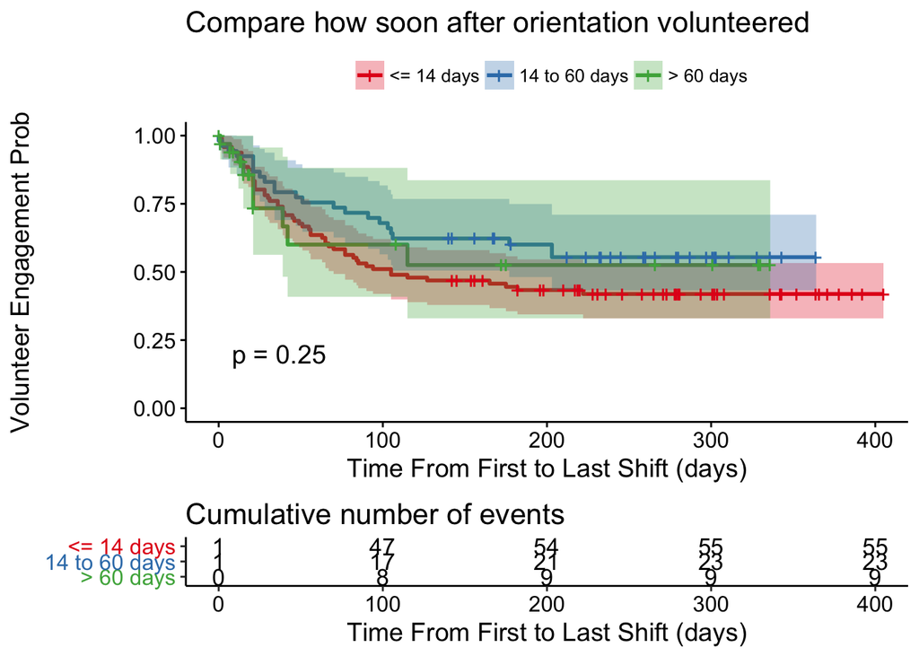

```r
ggsurvplot(surv.fit, data = model_data,
           surv.median.line = "hv",
           pval = TRUE, conf.int = TRUE, cumevents = TRUE,
           ylab = "Volunteer Engagement Prob",
           palette = brewer.pal(n=9, "Set1"),
           xlab = "Time From First to Last Shift (days)",
           title = "Compare how soon after orientation volunteered",
           legend.title = "", legend.labs = levels(factor(model_data$first_shift_group)))
```

```r
surv.fit <- survfit(surv.model ~ timebw_shift_group, data = model_data)
surv.fit
```

```
## Call: survfit(formula = surv.model ~ timebw_shift_group, data = model_data)
##
##                                  n events median 0.95LCL 0.95UCL
## timebw_shift_group=<= 7 days    97     45    175      77      NA
## timebw_shift_group=7 to 14 days 49     23    203      84      NA
## timebw_shift_group=> 14 days    37     19    203     105      NA
```

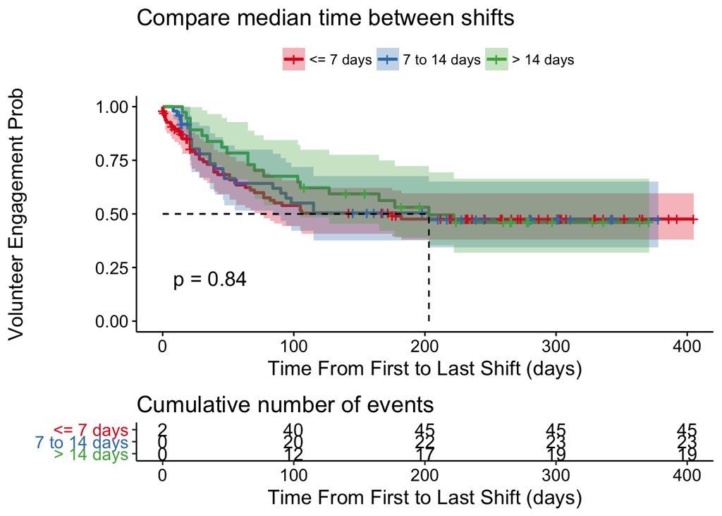

```r
ggsurvplot(surv.fit, data = model_data,
           surv.median.line = "hv",
           pval = TRUE, conf.int = TRUE, cumevents = TRUE,
           ylab = "Volunteer Engagement Prob",
           palette = brewer.pal(n=9, "Set1"),
           xlab = "Time From First to Last Shift (days)",
           title = "Compare median time between shifts",
           legend.title = "", legend.labs = levels(factor(model_data$timebw_shift_group)))
```

We don’t see a strong trend that volunteers leave sooner if they tend to volunteer more frequently or if they first volunteer soon or later after they complete orientation.

```r
# Could plot either total_time - time from orientation to last shift
# or time_last_to_first - time from first shift to last shift

model_data <- filter(final_data, total_shifts > 0, Orientation.Date.Primary <= "2017-09-01")
surv.model <- Surv(model_data$total_time, model_data$event)
surv.fit <- survfit(surv.model ~ only_one_shift, data = model_data)
surv.fit
```

```
## Call: survfit(formula = surv.model ~ only_one_shift, data = model_data)
##
##                        n events median 0.95LCL 0.95UCL
## only_one_shift=FALSE 183     87     NA     168      NA
## only_one_shift=TRUE   27     24     21      18     104
```

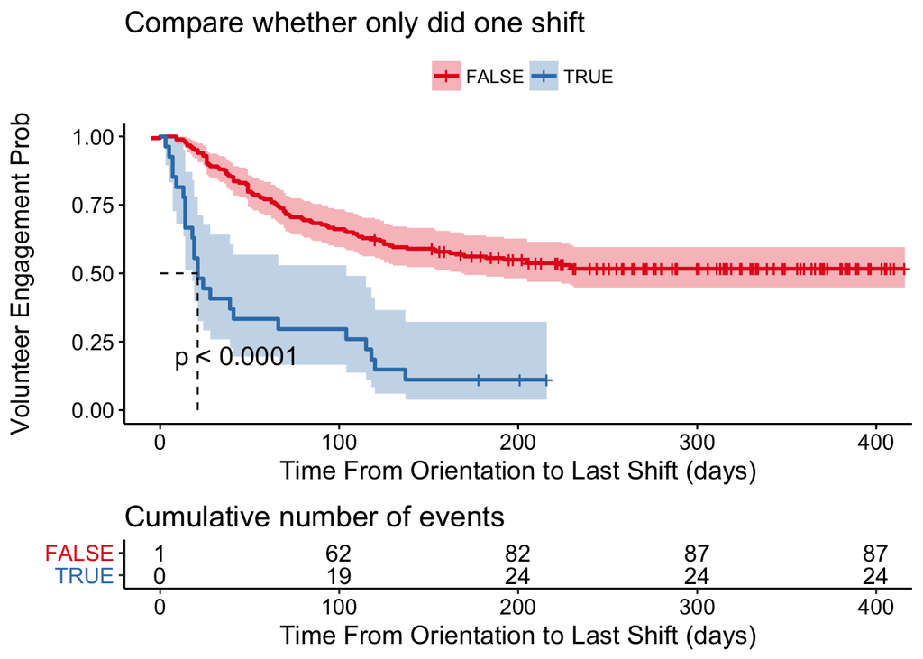

```r
ggsurvplot(surv.fit, data = model_data,
           surv.median.line = "hv",
           pval = TRUE, conf.int = TRUE, cumevents = TRUE,
           ylab = "Volunteer Engagement Prob",
           palette = brewer.pal(n=9, "Set1"),
           xlab = "Time From Orientation to Last Shift (days)",
           title = "Compare whether only did one shift",
           legend.title = "", legend.labs = levels(factor(model_data$only_one_shift)))
```

```r
# top assignments:
top_assign <- names(sort(table(final_data$primary_type),decreasing = T))[1:3]
model_data <- filter(final_data, total_shifts > 1,
                     Orientation.Date.Primary <= "2017-09-01",
                     primary_type %in% top_assign)

surv.model <- Surv(model_data$time_last_to_first, model_data$event)
surv.fit <- survfit(surv.model ~ primary_type, data = model_data)
surv.fit
```

```
## Call: survfit(formula = surv.model ~ primary_type, data = model_data)
##
##                                      n events median 0.95LCL 0.95UCL
## primary_type=Cat Care Volunteer    114     57    115      90      NA
## primary_type=Dog Care Volunteer     32     19     85      42      NA
## primary_type=Dog Walking Volunteer  33     10     NA      NA      NA
```

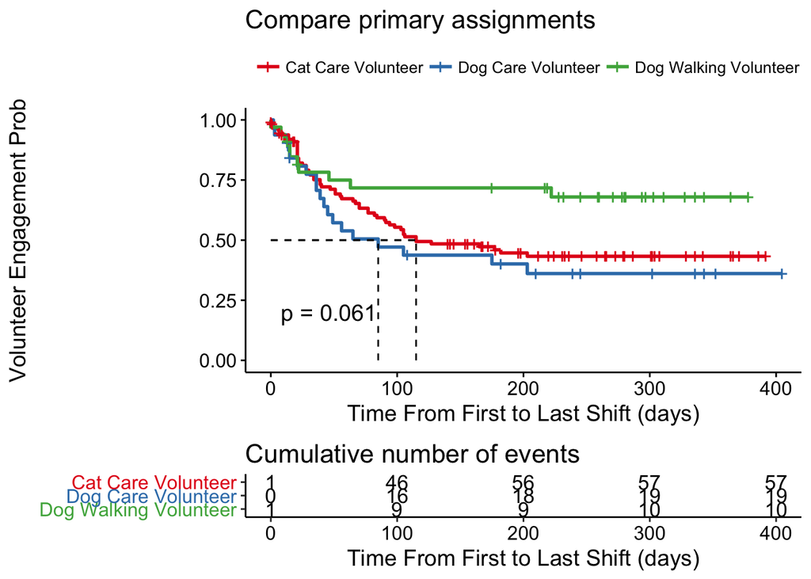

```r
ggsurvplot(surv.fit, data = model_data,
           surv.median.line = "hv",
           pval = TRUE, conf.int = FALSE, cumevents = TRUE,
           palette = brewer.pal(n=9, "Set1"),
           ylab = "Volunteer Engagement Prob", xlab = "Time From First to Last Shift (days)",
           title = "Compare primary assignments",
           legend.title = "", legend.labs = levels(factor(model_data$primary_type)))
```

```r
model_data <- filter(final_data, total_shifts > 1, Orientation.Date.Primary <= "2017-09-01")
surv.model <- Surv(model_data$time_last_to_first, model_data$event)
surv.fit <- survfit(surv.model ~ orient_loc.Primary, data = model_data)
surv.fit
```

```
## Call: survfit(formula = surv.model ~ orient_loc.Primary, data = model_data)
##
##                         n events median 0.95LCL 0.95UCL
## orient_loc.Primary=GF  52     26    105      49      NA
## orient_loc.Primary=NE  39     18    222      77      NA
## orient_loc.Primary=PAC 92     43    182     103      NA
```

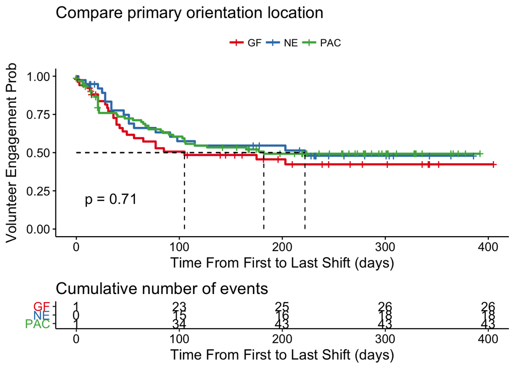

```r
ggsurvplot(surv.fit, data = model_data,
           surv.median.line = "hv",
           pval = TRUE, conf.int = FALSE, cumevents = TRUE,
           palette = brewer.pal(n=9, "Set1"),
           ylab = "Volunteer Engagement Prob", xlab = "Time From First to Last Shift (days)",
           title = "Compare primary orientation location",
           legend.title = "", legend.labs = levels(factor(model_data$orient_loc.Primary)))
```

```r
model_data <- filter(final_data, total_shifts > 1, Orientation.Date.Primary <= "2017-09-01")
surv.model <- Surv(model_data$time_last_to_first, model_data$event)
surv.fit <- survfit(surv.model ~ city_clean, data = model_data)
surv.fit
```

```
## Call: survfit(formula = surv.model ~ city_clean, data = model_data)
##
##                           n events median 0.95LCL 0.95UCL
## city_clean=other         39     18    222      63      NA
## city_clean=Philadelphia 144     69    177     103      NA
```

[figure not shown]

```r
ggsurvplot(surv.fit, data = model_data,
           surv.median.line = "hv",
           pval = TRUE, conf.int = FALSE, cumevents = TRUE,
           palette = brewer.pal(n=9, "Set1"),
           ylab = "Volunteer Engagement Prob", xlab = "Time From First to Last Shift (days)",
           title = "Compare primary orientation location",
           legend.title = "", legend.labs = levels(factor(model_data$city_clean)))
```

There is not a clear trend for orientation location or whether someone lives in philadelphia or outside philadelphia.

There is a trend that volunteers that typically volunteer as dog walking volunteers stay engaged longer than cat care of dog care volunteers. Cat care is at all three sites, dog care only at Grays Ferry and dog walking is either PAC or NE.